# Ordinal Logistic Regression with the Big Five

Author

Michaela Luceno

# 1. Configuring Analysis

```r
library(tidyverse)
library(readxl)
library(psych)
library(ordinal)
library(ggeffects)
library(broom)
library(gt)
```

## 1.3. Load and Inspect Analysis

## 1.4. Choosing Variables

This `bfi` data highlights the Big Five Personality index, with 5 personality traits/behaviours in each (25 total). Data was collected from 2800 people. Questions were answered on a 6-point Likert scale from *Very inaccurate* to *Very accurate*.

The **chosen trait is Extraversion**. The ordered outcome is part of Extraversion, **E4, “Make Friends easily.”** The predictor is a person’s **Agreeableness subscale score**, the mean of A1 to A5 with A1 reverse-keyed.

I predict that as people are more agreeable, that they will make friends more easily. I expect that the predictor of Agreeableness will be positively associated with higher scores in the ability to predict friends. This is because the trait of agreeableness centers around friendliness and getting along well with others, which is conducive to making friends easily.

## 1.5. Preparing the Analysis Data

```
[1] 4.653816
```

The *N* analyzed was the number of participants left after removing those with improper (incomplete/missing) data for E4. This number was N = 2791. The predictor was scored being the mean of 5 Agreeableness behaviours in the questionnaire, with A1 reverse scored and A2-A5 staying the same. The rest were scored from 106 with lower values representing less of the behavior. The mean was calculated with `mean(data$agree)`, which was 4.65.

# 2. Examining the Outcomes

## 2.1. The Ordered Outcome

```
# A tibble: 6 × 3
  E4                        n      p
  <ord>                 <int>  <dbl>
1 Very inaccurate         140 0.0502
2 Moderately inaccurate   262 0.0939
3 Slightly inaccurate     271 0.0971
4 Slightly accurate       450 0.161
5 Moderately accurate     942 0.338
6 Very accurate           726 0.260
```

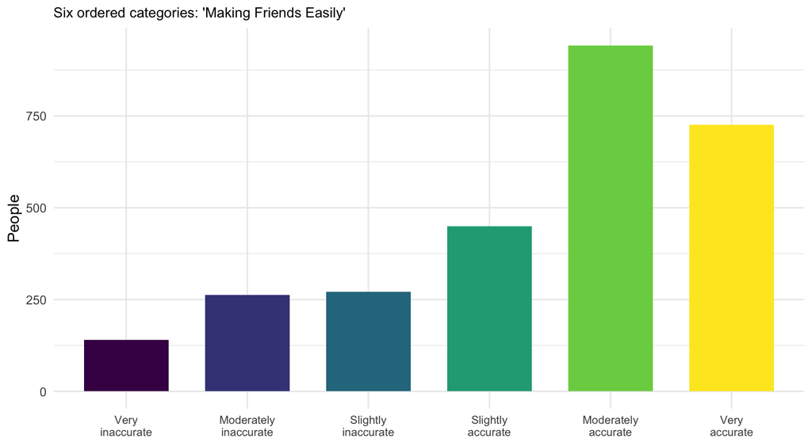

## 2.2. How Predictor Relates to the Outcome

### Jittered Dot Plots

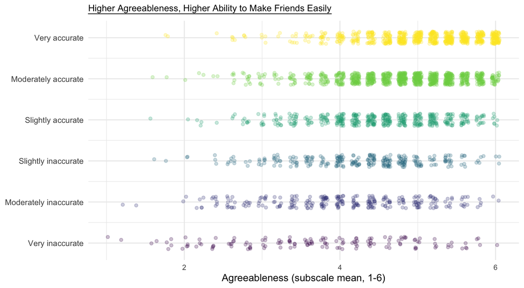

The pattern that is seen is higher density in that category and data that reflects those with high agreeableness responding that it is very and moderately accurate that they are easily able to make new friends. This is a good model to use, as the data being used is categorical and is separated based on specific levels of the data representing traits. Using a decimal average is not representative of one of the six Likert categories that were provided as an option of response, as they are not categories to be averaged, or having a meaning of numerical values.

## 2.3. An Unordered Outcome

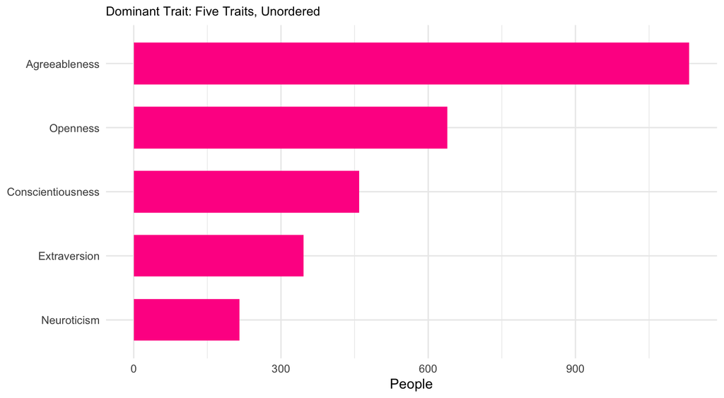

# 3. Cumulative Probabilities

## 3.1. Building a Cumulative Table

| Category in E4 (j) | n | P(Y = j) | P(Y ≤ j) | Odds of ≤ j | Log-odds of ≤ j |
| --- | --- | --- | --- | --- | --- |
| Very inaccurate | 140 | 0.050 | 0.050 | 0.05 | −2.94 |
| Moderately inaccurate | 262 | 0.094 | 0.144 | 0.17 | −1.78 |
| Slightly inaccurate | 271 | 0.097 | 0.241 | 0.32 | −1.15 |
| Slightly accurate | 450 | 0.161 | 0.402 | 0.67 | −0.40 |
| Moderately accurate | 942 | 0.338 | 0.740 | 2.84 | 1.05 |
| Very accurate | 726 | 0.260 | 1.000 | — | — |

Here, we are calculating cumulative probabilities, which are the probabilities of responding of a specific category (in this case, *j*), or something lower (i.e. selecting moderately inaccurate would also include what is below, such as very inaccurate); therefore, having 6 categories, this means that there are 5 cumulative probabilities and the sixth, adding all together would be 100%. This is why the last category would have undefined odds, becasue it incorporates everything above it. We are using these cumulative thresholds to later turn into probabilities. We will be using the function `cumsum()` to add these.

In order to compute these, we can split our scale in two at *j*, quantifying things as above or below *j*, allowing for the values to now become binary (before versus after) and can use other link functions such as the logit link function. This threshold is only 5 values, as it’s between each of the 6 categories to make the groupings, and there is a predetermined order that the values/outcomes will remain in.

# 4. Specify and Estimate Cumulative Logit Models

## 4.1. Explaining the Model

Keeping in mind that ordinal models have no fixed value between the ordered categories, and rather it relates to falling above or below certain categories as we’ve mentioned with *j* above, and these are specific thresholds as the categories move between one another.

## 4.2. Estimating Two Nested Models

We will use the function `clm()` to estimate the models.

| Model | Predictors | Purpose |
| --- | --- | --- |
| M0: Null | Thresholds Only | Baseline model |
| M1: Predictor | Centered Predictor | Evaluate if predictor is associated with outcome |

```
formula: E4 ~ agree_c
data:    data

 link  threshold nobs logLik   AIC     niter max.grad cond.H
 logit flexible  2791 -4210.46 8432.92 5(0)  1.70e-09 2.0e+01

Coefficients:
        Estimate Std. Error z value Pr(>|z|)
agree_c  0.97300    0.04225   23.03   <2e-16 ***
---
Signif. codes:  0 '***' 0.001 '**' 0.01 '*' 0.05 '.' 0.1 ' ' 1

Threshold coefficients:
                                          Estimate Std. Error z value
Very inaccurate|Moderately inaccurate     -3.30285    0.09223  -35.81
Moderately inaccurate|Slightly inaccurate -2.02296    0.05844  -34.61
Slightly inaccurate|Slightly accurate     -1.29478    0.04766  -27.17
Slightly accurate|Moderately accurate     -0.42166    0.04099  -10.29
Moderately accurate|Very accurate          1.22052    0.04602   26.52
```

## 4.3. Interpreting the Thresholds

```
    Very inaccurate|Moderately inaccurate
                               -3.3028480
Moderately inaccurate|Slightly inaccurate
                               -2.0229584
    Slightly inaccurate|Slightly accurate
                               -1.2947820
    Slightly accurate|Moderately accurate
                               -0.4216639
        Moderately accurate|Very accurate
                                1.2205208
                                  agree_c
                                0.9730030
```

| Category | Threshold above category | P(Y ≤ j) | P(Y = j) |
| --- | --- | --- | --- |
| Very inaccurate | −3.30 | 0.04 | 0.04 |
| Moderately inaccurate | −2.02 | 0.12 | 0.08 |
| Slightly inaccurate | −1.29 | 0.22 | 0.10 |
| Slightly accurate | −0.42 | 0.40 | 0.18 |
| Moderately accurate | 1.22 | 0.77 | 0.38 |
| Very accurate | — | 1.00 | 0.23 |

**Why Center the Predictor?** We will also center the mean, such that it becomes zero and all points can show variation around that. This alters the thresholds that we use to better assess the data. This also removes the ability of someone scoring a 0 on the 1-6 scale, which would also negatively impact analysis. This, however does not change the slope, in which the coefficients can show latent logit scale of agreeableness. This does not change the slope, because the mean is subtracted from each number, so even though the values change, the distance between then doesn’t thus keeping the slope the same. The estimated slope is beta = 0.973003. Higher Agreeableness decreases the the log-odds of being at or below each threshold, shifting values towards having higher Agreeableness values and higher slightly/moderately accurate values. The most likely response is *Moderately accurate* (0.3760365).

## 4.4 Checking the Null Model

In model M0, it is only the thresholds, and we must verify that that it is equal to the observed cumulative log-odds from previous sections.

```
    Very inaccurate|Moderately inaccurate
                               -2.9410498
Moderately inaccurate|Slightly inaccurate
                               -1.7821781
    Slightly inaccurate|Slightly accurate
                               -1.1464822
    Slightly accurate|Moderately accurate
                               -0.3956216
        Moderately accurate|Very accurate
                                1.0453355
```

```
[1] -2.9410498 -1.7821781 -1.1464822 -0.3956216  1.0453355
```

This output reflects the fact that the thresholds are just the cumulative log odds of all the data in the sample. However, when adding Agreeableness as a predictor, now the thresholds are conditional on the predictor and will therefore not match the previous log-odds, which are cumulative.

# 5. Compare and Select a Model

## 5.1. Comparing the Models

```
Likelihood ratio tests of cumulative link models:

         formula:     link: threshold:
null     E4 ~ 1       logit flexible
one_pred E4 ~ agree_c logit flexible

         no.par    AIC  logLik LR.stat df Pr(>Chisq)
null          5 8995.5 -4492.8
one_pred      6 8432.9 -4210.5  564.62  1  < 2.2e-16 ***
---
Signif. codes:  0 '***' 0.001 '**' 0.01 '*' 0.05 '.' 0.1 ' ' 1
```

| Model | Parameters | logLik | AIC | ΔAIC |
| --- | --- | --- | --- | --- |
| Null | 5 | −4,492.8 | 8,995.5 | 562.6 |
| Agreeableness | 6 | −4,210.5 | 8,432.9 | 0.0 |

It can be generally seen that with the addition of the Agreeableness predictor, there is a decrease in AIC and increase in LRT, both reflecting improved predictive ability. The Agreeableness model is preferred (ΔAIC = 562.6). Comparing M0 to M1 gave 564.62, with 1 degrees of freedom, and a p-value of < 0.001.

## 5.2 Interpreting Slope on Latent Scale

The slope on the latent logit scale is beta = 0.973003. The latent scale is a continuous scale which reflects the ease of making friends. Each one point increase in Agreeableness increases this latent scale of making friends by 0.973003.

The middle categories, being the adjacent thresholds, are each about 0.8006473, meaning that the one point of Agreeableness change alters their score on the latency continuum of making friends by 121.5270492%.

# 6. Checking Proportional Odds Assumptions

## 6.1. Testing Proportional Odds

When using a model that assumes proportional odds, there is the same slope used with the five thresholds. Therefore, we can refit a model using `nominal_test()` with a different slope for the predictor (Agreeableness) at each threshold, and compares the models to compare the models and determine if it fits better. If the new slope does not fit significantly better than the old one, then they can all maintain the same slope.

```
Tests of nominal effects

formula: E4 ~ agree_c
        Df  logLik    AIC    LRT Pr(>Chi)
<none>     -4210.5 8432.9
agree_c  4 -4209.7 8439.4 1.4773   0.8307
```

The LRT statistic is 1.477286, with 4 degrees of freedom, and finally with a p-value of 0.8306572. This means that the test is not significant, and therefore the shared slope may be used rather than an individual one for each threshold. If it was significant, we would have the fit a partial proportional odds model.

### Fitting Partial Proportional Odds Model in Needed

The previous results are insignificant, so no new model needs to be fitted, however these values will be needed for functions below.

```
    Very inaccurate|Moderately inaccurate.(Intercept)
                                           -3.3482512
Moderately inaccurate|Slightly inaccurate.(Intercept)
                                           -2.0461953
    Slightly inaccurate|Slightly accurate.(Intercept)
                                           -1.3117424
    Slightly accurate|Moderately accurate.(Intercept)
                                           -0.4305991
        Moderately accurate|Very accurate.(Intercept)
                                            1.2007962
        Very inaccurate|Moderately inaccurate.agree_c
                                           -1.0298282
    Moderately inaccurate|Slightly inaccurate.agree_c
                                           -1.0079823
        Slightly inaccurate|Slightly accurate.agree_c
                                           -1.0010445
        Slightly accurate|Moderately accurate.agree_c
                                           -0.9672324
            Moderately accurate|Very accurate.agree_c
                                           -0.9225678
```

# 7. Interpreting the Results

## 7.1. Interpreting the Odds Ratio

**Agreeableness** The odds ratio found for my predictor of Agreeableness is e^beta = 2.6458781, with the 95% CI being [2.4364666, 2.8753943], and finally a p-value of 2.3433206^{-117}.

These results mean that each one-point increase in Agreeableness multiplies the odds of responding above a threshold by a 165%, which is an increase in odds. This is because the slope of each threshold is the same, so the odds between each of them would be the same.

## 7.2. Translating Odds Ratio into Probabilities

| Agreeableness | P(Slightly accurate or higher) | Odds |
| --- | --- | --- |
| 3 | 0.42 | 0.73 |
| 4 | 0.66 | 1.93 |
| 5 | 0.84 | 5.11 |
| 6 | 0.93 | 13.53 |

## 7.3. Plotting Predicted Category Probabilities

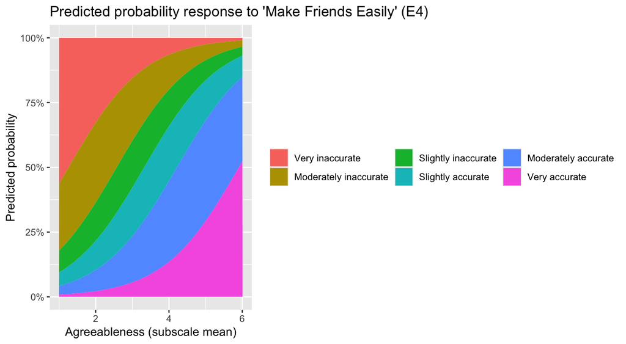

On the left, low levels of agreeableness are seen, which correspond with “Very inaccurate” then “Moderately inaccurate”, and as the subscale on the x axis increases, the probability is moved out of the lower category and more agreeable people are more likely to say that they make friends more easily.

## 7.4. Plot the Odds Ratio

The plot shows the shared proportional-odds OR alongside the threshold-specific ORs from Section 6, so it also works as a visual check of proportional odds.

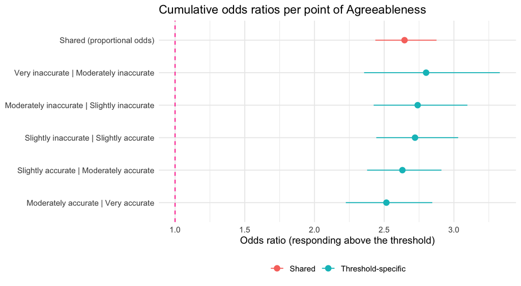

We can see that every interval is above (to the right of) 1.0, with the specific estimates remaining around their cluster, looking farily similar. This well represents the assumptions of proportional odds in agreement with each threshold being constant.

# 8. Results paragraph

The objective of this analysis was to understand the association between a predictor of the Big Five traits, in this case, Agreeableness, and how it may relate to an outcome which is characteristic of another trait. We used E4, ‘Makes friends easily’, which was part of the Extroversion scale. Each question within the traits was in terms of a 6-point Likert scale ranging from “Very inaccurate” (1), to “Very accurate” (6). In order to do so, we used a cumulative logit model, assuming proportional odds to assess how Agreeableness may predict ‘Making friends easily’, with N= 2,791. We additionally assessed the proportion of the sample in each category to ensure that no categories warranted being collapsed/combined from being too sparse. Additionally, we created two models: M0 (just the thresholds) and M1 (adding Agreeableness as a predictor). In this model, the predictor was centered, meaning that the average score = 0 with the other scores flanking (the mean was subtracted from each score). In this, we were able to assess that Agreeableness improved the fit through the *χ²* = (1) 564.6214237, the *p*< 8.3044573^{-125}, 1 as the *df* and *ΔAIC* = 562.6, with the lower AIC had by M1.

After this model was selected, we assessed the cumulative odds ratio, meaning reaching/exceeding a threshold or falling below it. As a whole, we were able to conclude that the more agreeable individuals were, it increased the odds of higher response of “Make friends easily” by 165%. The cumulative odds ratio was 2.6458781, *95% CI* being [2.4364666, 2.8753943], and a *p*< 0.001. Additionally, it was crucial that proportional odds assumptions were assessed, meaning that the predictor of agreeableness would be held across every threshold split of the outcome variable (and have the same slope). We found that this assumption did in face hold, with *χ²* = (4) 1.477286, *p*< 0.8306572, and therefore a partial proportional odds model was not needed. Additionally, we can report the probabilities of endorsing the item of making friends easily increased from of 0.42 at Agreeableness of 3 compared with 0.93 for a person with a high score of 6. To conclude, my prediction from Part 1, highlighting that higher levels of Agreeableness will be predictive of increased tendency to “Make friends easily” E4 was correct and supported as seen by positive association within the aforementioned data analysis.